# Constructing Community Performance Curves On The Right Scale

A general link-function view for LV and consumer-resource models

## Main Idea

A community performance curve (CPC) should not necessarily be constructed by summing raw species performance curves. It should be constructed by first mapping each species’ temperature-dependent performance onto the scale of the community variable whose stability we want to predict, and only then summing across species.

For stability of total abundance or total biomass, the species-level curve should therefore represent expected contribution to abundance or biomass, not just raw physiological performance or intrinsic growth rate.

The general construction is:

1. Compute each species’ temperature-dependent performance curve.
2. Transform each species’ performance to the scale of the focal community variable.
3. Sum the transformed species curves to obtain the CPC.
4. Use the temporal variability of that CPC to predict the stability of the focal community variable.

In notation:

$$P_i(T) = \text{raw performance of species } i \text{ at temperature } T$$

$$A_i(T) = f_{\text{model}, y}(P_i(T))$$

$$CPC_y(T) = \sum_i A_i(T)$$

where $y$ is the community variable whose stability is being predicted, such as total abundance or total biomass. The function $f_{\text{model}, y}$ is a model-specific link from raw species performance to expected contribution to that community variable.

## Why The Link Function Matters

When predicting the stability of total abundance or total biomass, the relevant question is not simply whether species have high or low raw performance. The relevant question is how changes in species performance translate into changes in species abundance or biomass.

If raw performance is approximately linearly related to abundance, then summing raw performance curves can be appropriate. But if abundance responds nonlinearly, or if performance mainly determines whether a species can persist at all, then raw performance is on the wrong scale. In that case, the species performance curve should first be transformed onto an abundance or biomass scale before constructing the CPC.

This gives a general rule:

> The CPC should be a sum of species’ expected contributions to the focal community variable, not necessarily a sum of raw species performance curves.

## Lotka-Volterra Model

In the Lotka-Volterra model used here, raw temperature-dependent performance is closely linked to expected abundance by the model structure. Specifically, the model links intrinsic growth rate and carrying capacity in a way that makes higher performance correspond approximately linearly to higher expected abundance.

This means that, for predicting stability of total abundance, the link function from performance to abundance-scale contribution can be treated as approximately identity:

$$f_{\text{LV}, abundance}(P_i(T)) \approx P_i(T)$$

So the LV abundance-scale CPC can be written as:

$$CPC_{\text{LV}}(T) = \sum_i P_i(T)$$

In words, each species contributes its raw performance value to the community performance curve. This is why the original CV of community performance is a reasonable predictor in the LV case: the scale of the summed curve is already close to the scale of the abundance response.

## Consumer-Resource Model

In the consumer-resource model, raw species performance is not linearly related to equilibrium abundance. Instead, intrinsic growth rate mainly determines whether a species can persist under the current thermal and resource context.

If growth is negative, the species declines to very low abundance. If growth is positive, the species can grow, but its eventual abundance is then determined by other conditions, including:

- resource supply;
- mortality;
- conversion efficiency;
- half-saturation constants;
- competition with other consumers for shared resources.

Therefore, for predicting stability of total abundance, the appropriate abundance-scale transformation is closer to a viability threshold than to an identity link:

$$f_{\text{CR}, abundance}(P_i(T)) =
\begin{cases}
1, & P_i(T) > 0 \\
0, & P_i(T) \le 0
\end{cases}$$

The consumer-resource abundance-scale CPC is then:

$$CPC_{\text{CR viability}}(T) =
\sum_i I(P_i(T) > 0)$$

where $I(P_i(T) > 0)$ is 1 when species $i$ has positive growth at temperature $T$, and 0 otherwise.

In words, the CPC is the number of viable species through time. Its CV measures how variable the viable species pool is under the temperature sequence.

## Implication For The Previous CPC

The previous CV of community performance summed raw species growth-rate curves. That is defensible for the LV model because raw performance is approximately on the abundance scale. But in the consumer-resource model, raw growth rate is not the abundance response. It mostly controls whether a species can persist, while the abundance of persistent species is shaped by resource-mediated interactions.

This explains why the raw-performance CPC can fail to predict stability in the consumer-resource model. It is summing performance on the wrong scale.

The viability-transformed CPC works better because it applies a model-specific link function before summing:

$$\text{raw performance} \rightarrow \text{expected abundance-scale contribution}
\rightarrow \text{community performance curve}$$

## Proposed General Definition

For any model and any focal community variable, define a CPC as:

$$CPC_y(T) = \sum_i f_{\text{model}, y}(P_i(T))$$

where:

- $P_i(T)$ is the raw species performance curve;
- $y$ is the community variable whose stability is being predicted;
- $f_{\text{model}, y}$ maps raw species performance to expected contribution to $y$;
- the CPC is formed only after this transformation.

For the current models and response variable:

| Model | Focal stability variable | Link from species performance to contribution |
| --- | --- | --- |
| Lotka-Volterra | Total abundance | Approximately identity |
| Consumer-resource | Total abundance | Binary viability, $I(P_i(T) > 0)$ |

This framing keeps the CPC concept general while allowing the species-level performance-to-abundance link to differ among models.

## Four Model-Link Cases

The figure below applies the same logic to actual simulation outputs. Stability is measured as (1 / CV_{total abundance}). The x-axis is the CV of the CPC constructed under each model-link combination.

For the Lotka-Volterra model, the identity-link CPC comes directly from the saved community-measures output. The binary-link CPC is calculated from the saved LV community objects and the saved temperature series by thresholding each species’ growth curve at zero before summing. For the consumer-resource model, both identity-link and binary-link CPC CVs come from the saved factorial community-measures output.

### Lotka-Volterra, Identity Link

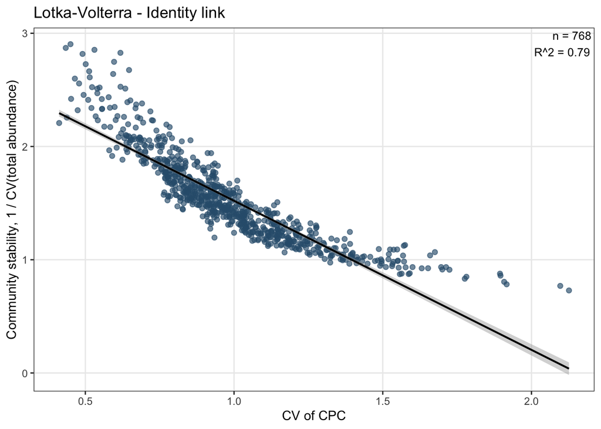

### Lotka-Volterra, Binary Link

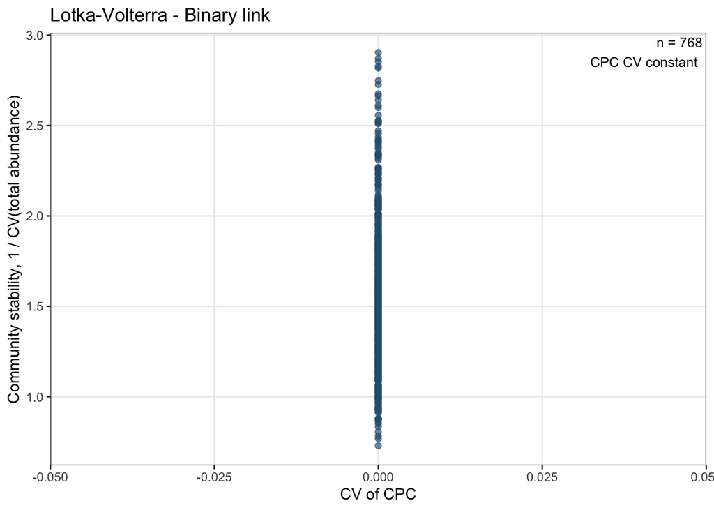

In this LV simulation set, the binary-link CPC is constant. The LV death parameter is zero, so the Gaussian intrinsic growth curve is positive for every species across the sampled temperature series. After thresholding at zero, each species is always viable, and the summed binary CPC has no temporal variation. This makes the binary-link CPC uninformative for this LV dataset.

### Consumer-Resource, Identity Link

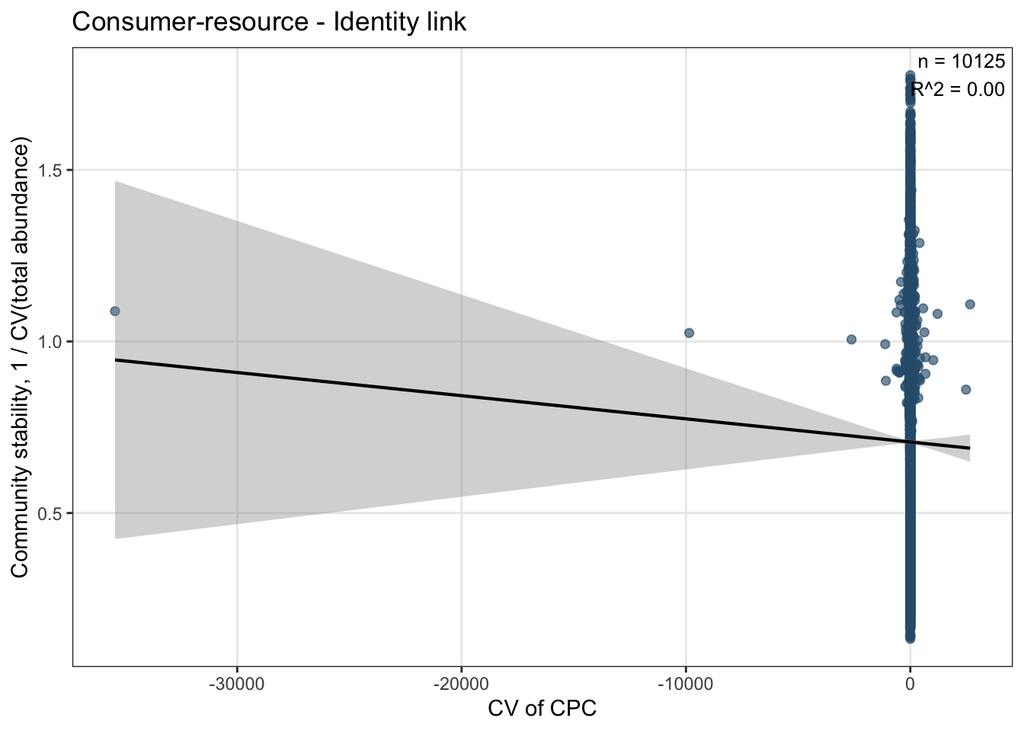

The identity-link CPC in the consumer-resource model has a few very large CV values. The same relationship with values above 50 excluded is:

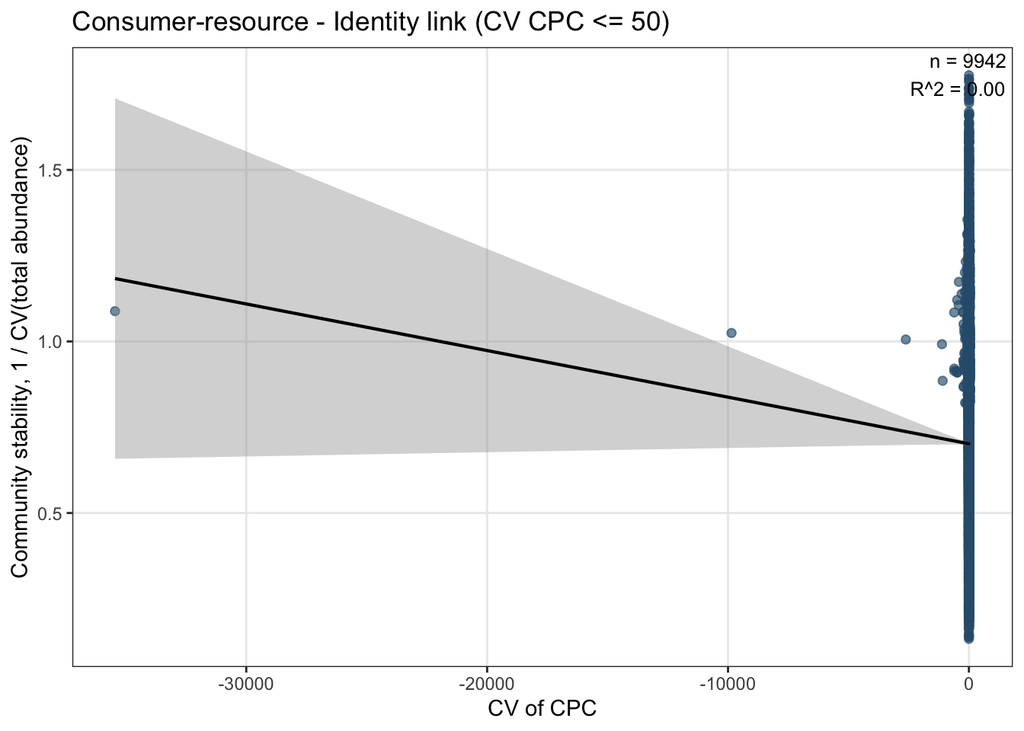

### Consumer-Resource, Binary Link

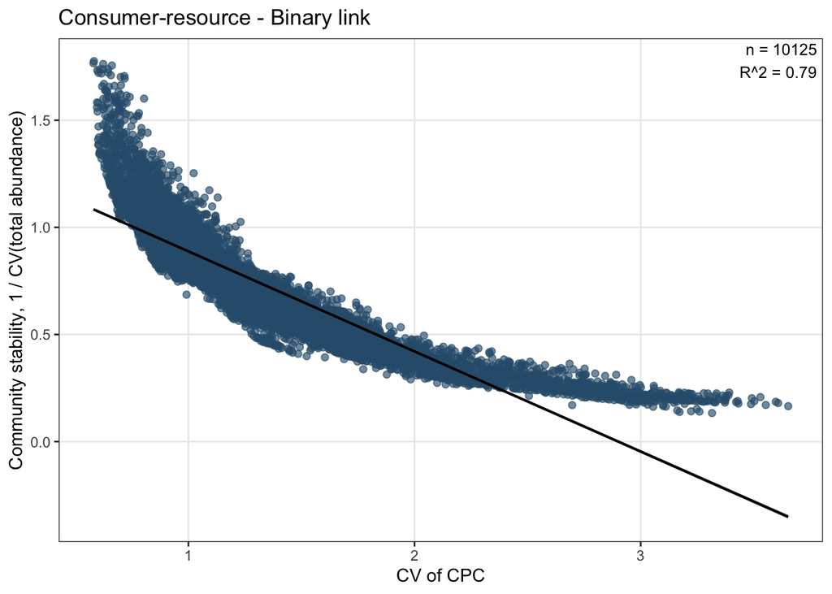

The expected pattern is visible in these simulations. The identity link is the appropriate scale transformation for the Lotka-Volterra model, while the binary viability link is much more informative for the consumer-resource model. The off-diagonal cases are useful controls: they show what happens when the CPC is constructed on a scale that is less closely tied to the abundance variable whose stability is being predicted.

## Practical Interpretation

When the focal response is total abundance or biomass stability, the CPC should answer this question:

> How much total abundance or biomass would the community be expected to support at each temperature, given the species that can contribute under that model?

In the LV model, species’ raw performance values already approximate their expected abundance contributions. In the consumer-resource model, the first-order abundance contribution is closer to whether each species is viable at all.

Thus, the strong predictive performance of `CV_community_viability_binary_info` in the small factorial consumer-resource experiment is not just an empirical accident. It supports the idea that CPCs should be constructed on the scale of the community variable whose stability is being predicted.